# 08-class-ds4ir-assignment

30-07-2020

# Assignment

1. Retorne ao primeiro exercício da aula e reproduza o gráfico de barras com a medida `betweenness` por família em ordem decrescente.
- **degree**: atribui uma pontuação de ao contabilizar quantas conexões diretas (entrada ou saída) cada nó possui. Útil para encontrar nós muito conectados.
- **closeness**: pontua cada nó com base em sua ‘proximidade’ com *todos os outros nós da rede*. Calcula os caminhos mais curtos entre todos os nós e atribui uma pontuação a cada nó com base na soma dos caminhos mais curtos.
- **betweenness**: mede o número de vezes que *um nó está no caminho mais curto entre outros nós*. Identifica as melhores “pontes” em uma rede para que o caminho de acesso a cada nó seja o mais curto possível.
- **pange rank**: atribui aos nós uma pontuação com base em suas conexões e nas conexões de suas conexões. Leva em consideração a direção e o peso do link. Útil para descobrir nós cuja influência se estende além de suas conexões diretas na rede mais ampla.

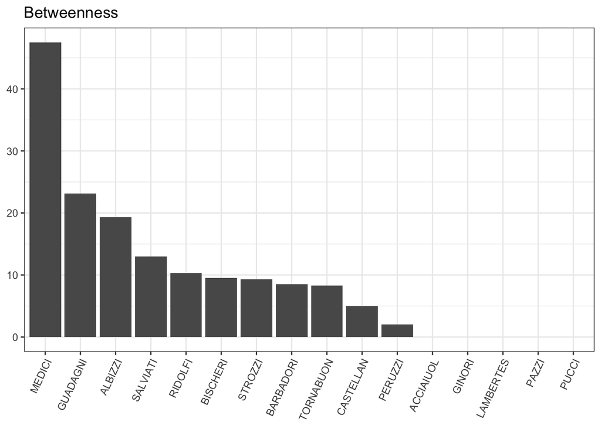

2. Reproduza o primeiro exemplo presente neste [link](https://raw.githubusercontent.com/jalapic/rmeetup_examples/master/networkD3_forceNetwork.R). Trata-se de parte do código de uma das referências listadas no material adicional.

```r
# random name function
random_name_df  <- function(nl = 100, size = 1000, smpl = 10, seed = 221) {
  df = data.frame(source = randomNames(size, which.names = 'both',
                                       name.order = 'first.last',
                                       name.sep = ' '), target = ''
                  )
  df = df[rep(seq_len(nrow(df)), sample(1:smpl, nrow(df), replace = T)), ]
  df = df[sample(nrow(df), nl), ]
  df$target = sample(df$source, nrow(df), replace = T)
  df = df[df[, 1] != df[, 2],]
  return(df)
}

# Basic Graph
df <- random_name_df(seed = 221)
g <- graph.data.frame(df, directed = F) # raw graph

## Make a vertices df
vertices <- data.frame(
  name = V(g)$name,
  group = edge.betweenness.community(g)$membership,
  betweenness = (betweenness(g, directed = F, normalized = T) * 115) + 0.1
)

# create indices (indexing needs to be JS format)
df$source.index = match(df$source, vertices$name) - 1
df$target.index = match(df$target, vertices$name) - 1
# head(df)

## fn1

# supply a edgelist + nodelist
forceNetwork(
  Links = df,
  Nodes = vertices,
  Source = 'source.index',
  Target = 'target.index',
  NodeID = 'name',
  Group = 'group',
  # color nodes by group calculated earlier
  charge = -50,
  # node repulsion
  linkDistance = 20,
  zoom = T,
  opacity = 1,
  fontSize = 24
)
```

[interactive chart not shown]

3. Produza um documento .html com o resultado de sua análise. No caso do item 2, é suficiente apresentar apenas seu código.

**Observação**: Não se esqueça de colocar seu nome.